# examples_0323

Consider the $L$-system (and turn angle) defined below:

- Start: `X`
- Rules:  
  `F > FF`  
  `X > FF[+XFFX+XF][-XFFX-XF]FXXFX`
- Number of recursions (number of iterations):
  - 3
- Turn angle
  - 30°

Please use [this online tool](https://artockthedino.github.io/lsys.html) to generate the pattern using turtle graphics. Choose the matching pattern. (The initial angle should be $270$ degrees to match the orientation.)

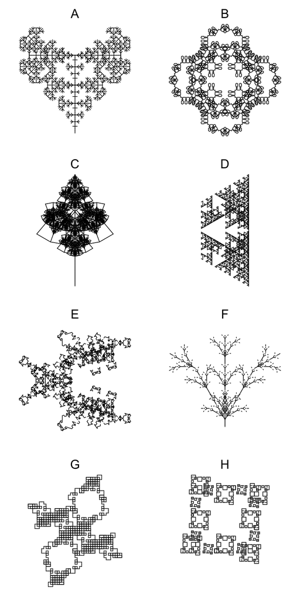

ABCDEFGH

The correct pattern is pattern F.

1. Use the first link: https://artockthedino.github.io/lsys.html
2. Copy/paste the `Axiom`, `Rules`, `Iterations`, and `Turn angle`.
3. Click `Generate Pattern`
4. Back to the quiz, select the matching pattern.

In case you're interested in the parameters of the other patterns shown:

## Pattern A

- Start: `A`
- Rules:  
  `A > AB`  
  `B > A[++C][--C]`  
  `C > C[+C][-C]A`
- Number of recursions (number of iterations):
  - 7
- Angle
  - 45

## Pattern B

- Start: `A+++A+++A+++A`
- Rules:  
  `A > B--B`  
  `B > AA+++AA`
- Number of recursions (number of iterations):
  - 7
- Angle
  - 30

## Pattern C

- Start: `A`
- Rules:  
  `A > CAA[--CAB][++CAB]`  
  `B > C[-CC-CA][+CC+CA]`  
  `C > CC`
- Number of recursions (number of iterations):
  - 5
- Angle
  - 100

## Pattern D

- Start: `A`
- Rules:  
  `A > +B-AAA-B+`  
  `B > -A+BBB+A-`
- Number of recursions (number of iterations):
  - 5
- Angle
  - 120

## Pattern E

- Start: `A`
- Rules:  
  `A > AXB+C+BXA`  
  `B > C--BAB--C`  
  `C > B+D-A-D+B`  
  `X > XX`  
  `D > DD`
- Number of recursions (number of iterations):
  - 5
- Angle
  - 72

## Pattern F

- Start: `X`
- Rules:  
  `F > FF`  
  `X > FF[+XFFX+XF][-XFFX-XF]FXXFX`
- Number of recursions (number of iterations):
  - 3
- Angle
  - 30

## Pattern G

- Start: `AA`
- Rules:  
  `A > B-AA-B`  
  `B > AB+B+A`
- Number of recursions (number of iterations):
  - 5
- Angle
  - 90

## Pattern H

- Start: `A`
- Rules:  
  `A > XX[B+BB+BB+BB+B]`  
  `X > XX`  
  `B > BA`
- Number of recursions (number of iterations):
  - 6
- Angle
  - 90

Consider the $L$-system (and turn angle) defined below:

- Start: `A++A++A++A`
- Rules:  
  `A > B-CAC-B`  
  `B > AB-BA`  
  `C > CC`
- Number of recursions (number of iterations):
  - 5
- Turn angle
  - 135°

Please use [this online tool](https://artockthedino.github.io/lsys.html) to generate the pattern using turtle graphics. Choose the matching pattern. (The initial angle should be $270$ degrees to match the orientation.)

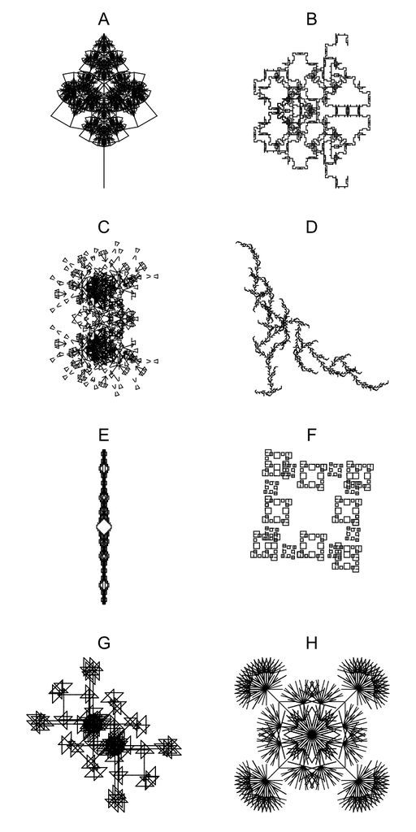

ABCDEFGH

The correct pattern is pattern G.

1. Use the first link: https://artockthedino.github.io/lsys.html
2. Copy/paste the `Axiom`, `Rules`, `Iterations`, and `Turn angle`.
3. Click `Generate Pattern`
4. Back to the quiz, select the matching pattern.

In case you're interested in the parameters of the other patterns shown:

## Pattern A

- Start: `A`
- Rules:  
  `A > CAA[--CAB][++CAB]`  
  `B > C[-CC-CA][+CC+CA]`  
  `C > CC`
- Number of recursions (number of iterations):
  - 5
- Angle
  - 100

## Pattern B

- Start: `A`
- Rules:  
  `A > +BA+A-ABA-A+AB+`  
  `B > +BA-B--B-AB+`
- Number of recursions (number of iterations):
  - 4
- Angle
  - 90

## Pattern C

- Start: `A`
- Rules:  
  `A > AXB+C+BXA`  
  `B > C--BAB--C`  
  `C > B+D-A-D+B`  
  `X > XX`  
  `D > DD`
- Number of recursions (number of iterations):
  - 5
- Angle
  - 108

## Pattern D

- Start: `A++++A`
- Rules:  
  `A > +A-B-B[B]`  
  `B > -B+A+A[A]`
- Number of recursions (number of iterations):
  - 5
- Angle
  - 45

## Pattern E

- Start: `A--A`
- Rules:  
  `A > +B-CAC-B+`  
  `B > -A+B+A-`  
  `C > CC`
- Number of recursions (number of iterations):
  - 6
- Angle
  - 90

## Pattern F

- Start: `A`
- Rules:  
  `A > XX[B+BB+BB+BB+B]`  
  `X > XX`  
  `B > BA`
- Number of recursions (number of iterations):
  - 6
- Angle
  - 90

## Pattern G

- Start: `A++A++A++A`
- Rules:  
  `A > B-CAC-B`  
  `B > AB-BA`  
  `C > CC`
- Number of recursions (number of iterations):
  - 5
- Angle
  - 135

## Pattern H

- Start: `[A]------------[A]`
- Rules:  
  `A > [---BC][+++BC]`  
  `B > [--AC][++AC]`  
  `C > F[-BA][+BA]`  
  `F > FF`
- Number of recursions (number of iterations):
  - 5
- Angle
  - 15

Consider the $L$-system (and turn angle) defined below:

- Start: `[A]+[A]+[A]+[A]`
- Rules:  
  `A > AA[-B][+B]B`  
  `B > [-ABC][+ABC]`  
  `C > A[-CB][+CB]`
- Number of recursions (number of iterations):
  - 4
- Turn angle
  - 90°

Please use [this online tool](https://artockthedino.github.io/lsys.html) to generate the pattern using turtle graphics. Choose the matching pattern. (The initial angle should be $270$ degrees to match the orientation.)

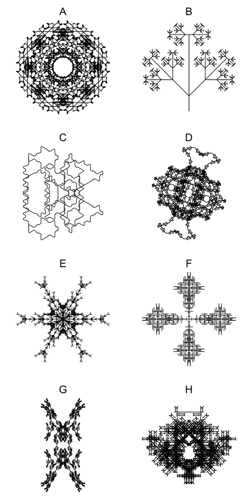

ABCDEFGH

The correct pattern is pattern F.

1. Use the first link: https://artockthedino.github.io/lsys.html
2. Copy/paste the `Axiom`, `Rules`, `Iterations`, and `Turn angle`.
3. Click `Generate Pattern`
4. Back to the quiz, select the matching pattern.

In case you're interested in the parameters of the other patterns shown:

## Pattern A

- Start: `A-A-A-A-A-A-A-A`
- Rules:  
  `A > +B-CAC-B+`  
  `B > -A++BB++A-`  
  `C > CC`
- Number of recursions (number of iterations):
  - 6
- Angle
  - 45

## Pattern B

- Start: `A`
- Rules:  
  `A > C[+CA][CCCCB][-CA]`  
  `B > [++A][--A]`  
  `C > CC`
- Number of recursions (number of iterations):
  - 6
- Angle
  - 45

## Pattern C

- Start: `A`
- Rules:  
  `A > ADB+D+BDA`  
  `B > C-DAD-C`  
  `C > B+A-D-A+B`  
  `D > DD`
- Number of recursions (number of iterations):
  - 5
- Angle
  - 60

## Pattern D

- Start: `A`
- Rules:  
  `A > +BA+ABCBA+AB+`  
  `B > -C+++BACAB+++C-`  
  `C > CC`
- Number of recursions (number of iterations):
  - 5
- Angle
  - 108

## Pattern E

- Start: `A++++A++++A`
- Rules:  
  `A > [+BCC][-BCC]`  
  `B > B[-CA][+CA]`  
  `C > CCA`
- Number of recursions (number of iterations):
  - 5
- Angle
  - 30

## Pattern F

- Start: `[A]+[A]+[A]+[A]`
- Rules:  
  `A > AA[-B][+B]B`  
  `B > [-ABC][+ABC]`  
  `C > A[-CB][+CB]`
- Number of recursions (number of iterations):
  - 4
- Angle
  - 90

## Pattern G

- Start: `A++++++A`
- Rules:  
  `A > +B-AXBXA-B+`  
  `B > -A+BXAXB+A-`  
  `X > XX`
- Number of recursions (number of iterations):
  - 5
- Angle
  - 150

## Pattern H

- Start: `ABA`
- Rules:  
  `A > +B--A--B+`  
  `B > -A+BCB+A-`  
  `C > CC`
- Number of recursions (number of iterations):
  - 7
- Angle
  - 45

Consider the $L$-system (and turn angle) defined below:

- Start: `A`
- Rules:  
  `A > +BA--AA--AB+`  
  `B > -AB++BB++BA-`
- Number of recursions (number of iterations):
  - 5
- Turn angle
  - 30°

Please use [this online tool](https://artockthedino.github.io/lsys.html) to generate the pattern using turtle graphics. Choose the matching pattern. (The initial angle should be $270$ degrees to match the orientation.)

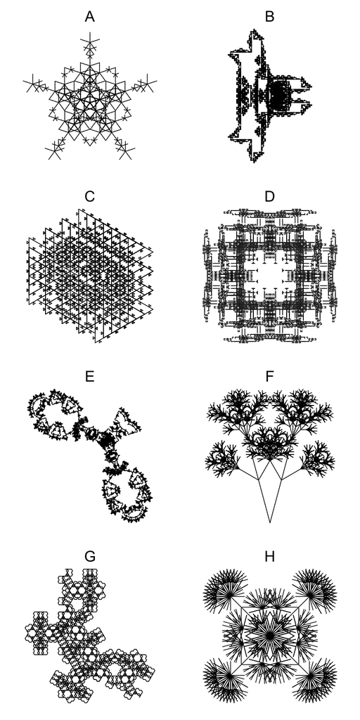

ABCDEFGH

The correct pattern is pattern G.

1. Use the first link: https://artockthedino.github.io/lsys.html
2. Copy/paste the `Axiom`, `Rules`, `Iterations`, and `Turn angle`.
3. Click `Generate Pattern`
4. Back to the quiz, select the matching pattern.

In case you're interested in the parameters of the other patterns shown:

## Pattern A

- Start: `A`
- Rules:  
  `A > [-AAB][--AAB][+AAB][++AAB]AAB`  
  `B > [-C][+C][--C][++C]CA`  
  `C > CC`
- Number of recursions (number of iterations):
  - 3
- Angle
  - 72

## Pattern B

- Start: `A`
- Rules:  
  `A > A--CBC--A`  
  `B > B+A+B`  
  `C > -CB+BC-`
- Number of recursions (number of iterations):
  - 7
- Angle
  - 90

## Pattern C

- Start: `A`
- Rules:  
  `A > +BA-A--A--A-AB+`  
  `B > -AB+B++B++B+BA-`
- Number of recursions (number of iterations):
  - 5
- Angle
  - 120

## Pattern D

- Start: `A+A+A+A`
- Rules:  
  `A > +B-AXBACABXA-B+`  
  `B > -A+BXA+C+AXB+A-`  
  `C > CC`  
  `X > XXX`
- Number of recursions (number of iterations):
  - 4
- Angle
  - 90

## Pattern E

- Start: `BB`
- Rules:  
  `A > +BA+A-ABA-A+AB+`  
  `B > +BBA-B--B-ABB+`
- Number of recursions (number of iterations):
  - 4
- Angle
  - 69

## Pattern F

- Start: `C`
- Rules:  
  `A > F[---BC][+++BC]`  
  `B > F[-CA][+CA]`  
  `C > [-AB][+AB]`  
  `F > FF`
- Number of recursions (number of iterations):
  - 6
- Angle
  - 15

## Pattern G

- Start: `A`
- Rules:  
  `A > +BA--AA--AB+`  
  `B > -AB++BB++BA-`
- Number of recursions (number of iterations):
  - 5
- Angle
  - 30

## Pattern H

- Start: `[A]------------[A]`
- Rules:  
  `A > [---BC][+++BC]`  
  `B > [--AC][++AC]`  
  `C > F[-BA][+BA]`  
  `F > FF`
- Number of recursions (number of iterations):
  - 5
- Angle
  - 15